# Week 4 Practical Machine Learning Project

June Kieu

September 2, 2019

## Summary

The goal of this project is to predict the manner in which users did the exercise. This is variable *classe* in training set. This report will describe my process of building the model.

## Loading Data

The first step is to load the data. There are cells with values of “NA” and “#DIV/0!” or missing. I decided to replace them with the median of the variables.

```r
rm(list=ls())
setwd("C:/Users/June Kieu/Downloads")
getwd()
```

```
## [1] "C:/Users/June Kieu/Downloads"
```

```r
training <- read.csv("pml-training.csv",sep = ",",na.strings=c("NA","","#DIV/0!"))
training <- training[-c(1:8)]#taking out the first 8 columns as they are not real predictors
testing <- read.csv("pml-testing.csv",sep = ",",na.strings=c("NA","","#DIV/0!"))
testing <- testing[-c(1:8)]#taking out the first 8 columns as they are not real predictors
dim(training);dim(testing)
```

```
## [1] 19622   152
```

```
## [1]  20 152
```

```r
#Replacing all NA cells with median value of the corresponding
#column for both training and testing set
for(i in 1:151){
  training[is.na(training[,i]), i] <- median(training[,i], na.rm = TRUE)
}
for(i in 1:151){
  testing[is.na(testing[,i]), i] <- median(testing[,i], na.rm = TRUE)
}
```

## Preparing data set for modeling

Training data set consists of 19,622 observations; using all of these to build the classification model is not recommended; as we cannot evaluate the model performance. Thus, I used *createDataPartition* function in package *caret* to split *training* data set into *TrainSet* and *TestSet*.

Also, there are variables with no or not significant variance; I excluded those out of *TrainSet* and *TestSet*. There are only 51 independent variables brought in the model.

```r
require(caret)
```

```r
require(ggplot2)
inTrain <- createDataPartition(training$classe,p=.6,list = FALSE)
TrainSet <- training[inTrain,]
TestSet <- training[-inTrain,]
###eliminating variables with near zero variance
NZV <- nearZeroVar(TrainSet)
TrainSet <- TrainSet[, -NZV]
TestSet <- TestSet[, -NZV]
testing1  <- testing[, -NZV]
dim(TrainSet)
```

```
## [1] 11776    52
```

## Modeling Step

Because the processing time for “rf” method using *caret* package is quite long, I decided to use “ranger” method instead. One of the parameters in *train* function regulates the method of cross validation, I decided to use *repeatedcv* method with 10-fold cross validations, which means dividing the data into 10 subsets, using 9 of them to train the model and 1 to test the performance. The process is repeated 3 times.

```r
set.seed(123)
fitControl <- trainControl(method = "repeatedcv",
                           number = 10,
                           repeats = 3)
RFMod <- train(classe~.,
                    data=TrainSet,
                    method="ranger",
                    trControl=fitControl,
               importance = "impurity")
preRFMod <- predict(RFMod,newdata=TestSet)
confusionMatrix(preRFMod,TestSet$classe)
```

```
## Confusion Matrix and Statistics
##
##           Reference
## Prediction    A    B    C    D    E
##          A 2226    7    0    0    0
##          B    6 1506   10    0    0
##          C    0    4 1358   16    1
##          D    0    1    0 1267    0
##          E    0    0    0    3 1441
##
## Overall Statistics
##
##                Accuracy : 0.9939
##                  95% CI : (0.9919, 0.9955)
##     No Information Rate : 0.2845
##     P-Value [Acc > NIR] : < 2.2e-16
##
##                   Kappa : 0.9923
##
##  Mcnemar's Test P-Value : NA
##
## Statistics by Class:
##
##                      Class: A Class: B Class: C Class: D Class: E
## Sensitivity            0.9973   0.9921   0.9927   0.9852   0.9993
## Specificity            0.9988   0.9975   0.9968   0.9998   0.9995
## Pos Pred Value         0.9969   0.9895   0.9848   0.9992   0.9979
## Neg Pred Value         0.9989   0.9981   0.9985   0.9971   0.9998
## Prevalence             0.2845   0.1935   0.1744   0.1639   0.1838
## Detection Rate         0.2837   0.1919   0.1731   0.1615   0.1837
## Detection Prevalence   0.2846   0.1940   0.1758   0.1616   0.1840
## Balanced Accuracy      0.9980   0.9948   0.9947   0.9925   0.9994
```

## Important Variables

pitch_forearm, yaw_belt, magnet_dumbbell_z, roll_forearm and roll_forearm are among top variables of RFMod. Below is a visualization of my model’s top 20 variables and their importances. The model then is used for *testing* set to predict classe for its 20 observations.

```
## ranger variable importance
##
##   only 20 most important variables shown (out of 51)
##
##                      Overall
## pitch_forearm         100.00
## yaw_belt               91.29
## magnet_dumbbell_z      85.87
## roll_forearm           54.71
## magnet_dumbbell_y      52.28
## pitch_belt             46.68
## roll_dumbbell          44.00
## magnet_dumbbell_x      40.67
## magnet_belt_y          38.87
## magnet_belt_z          36.26
## magnet_arm_x           28.48
## roll_arm               27.93
## gyros_belt_z           27.67
## accel_belt_z           27.57
## total_accel_dumbbell   26.38
## total_accel_belt       26.28
## accel_dumbbell_y       24.90
## accel_dumbbell_z       24.88
## accel_forearm_x        23.64
## accel_forearm_z        21.63
```

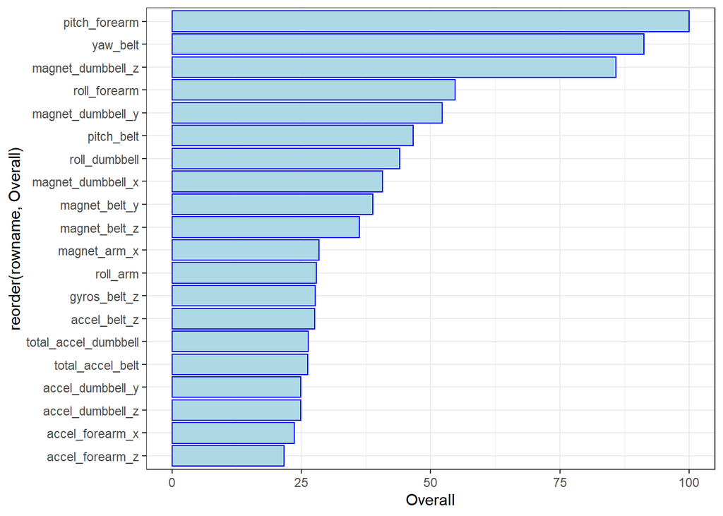

```
##  [1] B A A A A E D B A A B C B A E E A B B B
## Levels: A B C D E
```